## SEURAT WRAPPER TO REPORT SIGNIFICANT MARKERS AND REACTOME PATHWAYS

A new Seurat user is generally interested to run the single cell pipeline with less effort, quickly look at the expressed markers in different clusters and identify the pathways of interest within each cluster. This repository is a simple R package that has 4 functions:

[1]. SeuratPreprocess Function to convert Counts Data to Normalized and Scaled Seurat object for highly variable genes.

[2]. SeuratLowDim Function to convert Scaled Seurat Object from [1] to object that has clusters identified and data transformed to visualize in 2d (ie, PCA followed by t-SNE and UMAP).

[4]. ReactomeData Function to convert seurat object to get the pathways identified using ReactomeGSA R package.

```r
library(Seurat)
library(ReactomeGSA)
library(scReport)
```

```r
# Loading sample counts data (Mouse cell atlas)
mca.matrix <- readRDS(file = "data/MCA_merged_mat.rds")
mca.metadata <- read.csv(file = "data/MCA_All-batch-removed-assignments.csv", row.names = 1)
mca.matrix.10K <- mca.matrix[,1:10000]
```

## [1]. Function to convert Counts Data to Normalized and Scaled Seurat object for highly variable genes.

## [2]. Function to convert Scaled Seurat Object from [1] to object that has clusters identified and data transformed to visualize in 2d (ie, PCA followed by t-SNE and UMAP).

```r
scaled_seurat_object <- SeuratPreprocess(mca.matrix.10K)
```

```
## Normalizing layer: counts
```

```
## Finding variable features for layer counts
```

```r
low_dim_object <- SeuratLowDim(scaled_seurat_object)
```

```
## PC_ 1
## Positive:  Gsta4, Wfdc2, Sptssb, Sprr1a, Krt7
## Negative:  Retnlg, Chil3, Elane, Mpo, Srgn
## PC_ 2
## Positive:  Retnlg, Chil3, Elane, Mpo, Igkc
## Negative:  Col3a1, Col1a2, Sparc, Dcn, Col1a1
## PC_ 3
## Positive:  Tagln, Myl9, Acta2, Myh11, Pcp4l1
## Negative:  Clec3b, Dpt, Htra3, Lum, Col14a1
## PC_ 4
## Positive:  Acta2, Myl9, Tagln, Myh11, Tpm2
## Negative:  Emcn, Plvap, Egfl7, Pecam1, Mmrn2
## PC_ 5
## Positive:  Tnc, Car3, Cxcl14, Rbp4, Dkk2
## Negative:  Plvap, Emcn, Esam, Jam2, Ecscr
```

```
## Modularity Optimizer version 1.3.0 by Ludo Waltman and Nees Jan van Eck
##
## Number of nodes: 9801
## Number of edges: 580875
##
## Running Louvain algorithm...
## Maximum modularity in 10 random starts: 0.7313
## Number of communities: 35
## Elapsed time: 4 seconds
```

## [4]. Next, we use Reactome GSA R package to identify the pathways of interest using the cluster information of Seurat object.

```r
Reactome_pathways_object <- ReactomeData(low_dim_object)
```

```
## Converting expression data to string... (This may take a moment)
```

```
## Conversion complete
```

```
## Compressing request data...
```

```
## Reactome Analysis submitted succesfully
```

## Here is a quick glimpse of the output objects and tables outputted.

```r
scaled_seurat_object
```

```
## An object of class Seurat
## 18330 features across 9801 samples within 1 assay
## Active assay: RNA (18330 features, 2000 variable features)
##  3 layers present: counts, data, scale.data
```

```r
low_dim_object
```

```
## An object of class Seurat
## 18330 features across 9801 samples within 1 assay
## Active assay: RNA (18330 features, 2000 variable features)
##  3 layers present: counts, data, scale.data
##  3 dimensional reductions calculated: pca, tsne, umap
```

```r
Reactome_pathways_object[1]
```

```
## [[1]]
## ReactomeAnalysisResult object
##   Reactome Release: 88
##   Results:
##   - Seurat:
##     1823 pathways
##     7811 fold changes for genes
##   No Reactome visualizations available
```

```r
Reactome_pathways_object[3]
```

```
## [[1]]
##                                                                                                                                               name
## R-HSA-9037628                                                                                                      Rhesus blood group biosynthesis
## R-HSA-2142696                                                                                    Synthesis of Hepoxilins (HX) and Trioxilins (TrX)
## R-HSA-975574                                                                           Reactions specific to the hybrid N-glycan synthesis pathway
## R-HSA-140180                                                                                                                         COX reactions
## R-HSA-391906                                                                                                                 Leukotriene receptors
## R-HSA-2855086                                                       Ficolins bind to repetitive carbohydrate structures on the target cell surface
## R-HSA-373756                                                                                                                      SDK interactions
## R-HSA-9636003                                                                                                    NEIL3-mediated resolution of ICLs
## R-HSA-3296197                                                                                             Hydroxycarboxylic acid-binding receptors
## R-HSA-163316                                                                                               Mitochondrial transcription termination
## R-HSA-9024909                                                                                                BDNF activates NTRK2 (TRKB) signaling
## R-HSA-9025046                                                                                                NTF3 activates NTRK2 (TRKB) signaling
## R-HSA-156587                                                                                                                Amino Acid conjugation
## R-HSA-159424                                                                                                       Conjugation of carboxylic acids
## R-HSA-177128                                                                                                Conjugation of salicylate with glycine
## R-HSA-177135                                                                                                  Conjugation of benzoate with glycine
## R-HSA-390650                                                                                                                   Histamine receptors
## R-HSA-209822                                                                                                                 Glycoprotein hormones
## R-HSA-173599                                                                                     Formation of the active cofactor, UDP-glucuronate
## R-HSA-1855231                                                                                                     Synthesis of IPs in the ER lumen
## R-HSA-140834                                                                                            Extrinsic Pathway of Fibrin Clot Formation
## R-HSA-8964540                                                                                                                   Alanine metabolism
## R-HSA-112308                                                                                Presynaptic depolarization and calcium channel opening
## R-HSA-432030                                                                      Transport of glycerol from adipocytes to the liver by Aquaporins
## R-HSA-1483076                                                                                                                      Synthesis of CL
## R-HSA-190239                                                                                                   FGFR3 ligand binding and activation
## R-HSA-190372                                                                                                  FGFR3c ligand binding and activation
## R-HSA-190375                                                                                                  FGFR2c ligand binding and activation
## R-HSA-5263617                                                                                            Metabolism of ingested MeSeO2H into MeSeH
## R-HSA-880009                                                                              Interconversion of 2-oxoglutarate and 2-hydroxyglutarate
## R-HSA-211957                                                                      Aromatic amines can be N-hydroxylated or N-dealkylated by CYP1A2
## R-HSA-2142670                                                                    Synthesis of epoxy (EET) and dihydroxyeicosatrienoic acids (DHET)
## R-HSA-5632681                                                                                                         Ligand-receptor interactions
## R-HSA-173736                                                                                                     Alternative complement activation
## R-HSA-1475029                                                                                               Reversible hydration of carbon dioxide
## R-HSA-2142850                                                                                                   Hyaluronan biosynthesis and export
## R-HSA-217271                                                                                                             FMO oxidises nucleophiles
## R-HSA-141334                                                                                                     PAOs oxidise polyamines to amines
```

[output cut: 3594 more lines]

```
## R-HSA-5607761  1.207444e-01  0.156733624 0.03598921
## R-HSA-9711097  1.635316e-01  0.199520600 0.03598897
## R-HSA-5610785  8.812532e-02  0.123590500 0.03546518
## R-HSA-381771   6.903440e-02  0.104299100 0.03526470
## R-HSA-5610783  8.800862e-02  0.123122300 0.03511368
## R-HSA-8951664  7.674291e-02  0.111226272 0.03448336
## R-HSA-5621481  1.003424e-01  0.134296600 0.03395418
## R-HSA-5358351  6.869713e-02  0.102353070 0.03365594
## R-HSA-1299316  4.563715e-01  0.489891700 0.03352024
## R-HSA-3371571  6.389022e-02  0.097380620 0.03349040
## R-HSA-917937   1.144918e-01  0.146545000 0.03205318
## R-HSA-5610787  8.234454e-02  0.114068900 0.03172436
## R-HSA-9707616  4.760891e-02  0.079169560 0.03156065
## R-HSA-3371511  3.839851e-02  0.069254005 0.03085550
## R-HSA-1655829  3.586947e-02  0.066652190 0.03078272
```

Pathways of interest:

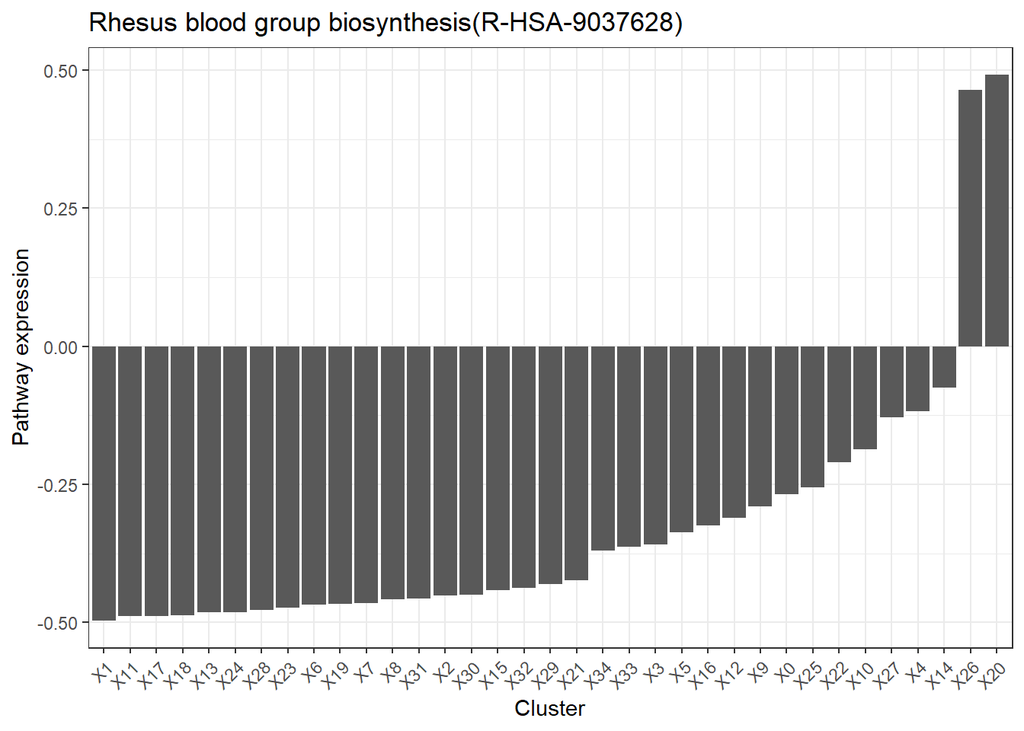

```r
plot_gsva_pathway(Reactome_pathways_object[[1]], pathway_id = rownames(Reactome_pathways_object[[3]])[1])
```

Same pathways showed as a heatmap:

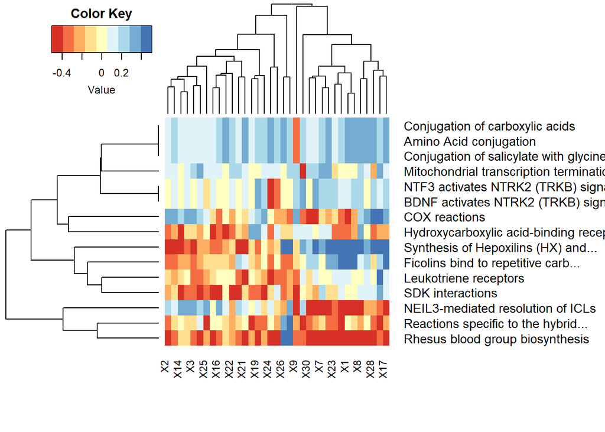

```r
plot_gsva_heatmap(Reactome_pathways_object[[1]], max_pathways = 15)
```

Relevant pathways based on user’s list:

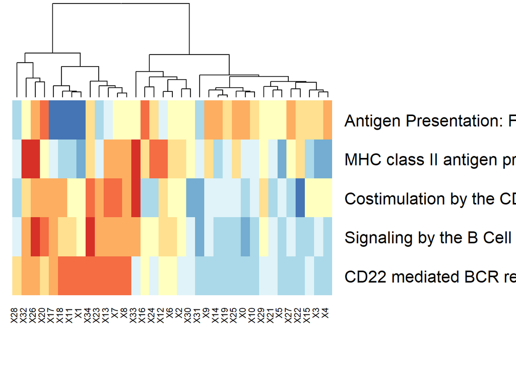

```r
relevant_pathways <- c("R-HSA-983170", "R-HSA-388841", "R-HSA-2132295", "R-HSA-983705", "R-HSA-5690714")
plot_gsva_heatmap(Reactome_pathways_object[[1]],
                  pathway_ids = relevant_pathways,
                  dendrogram = "col",
                  scale = "row", # scale for each pathway
                  key = FALSE,
                  lwid=c(0.1,4))
```